# Lectures 7 and 8 Code

Alex Hoagland

2022-08-12

```r
################################################################################
# I like to include several additional notes in the header of my files here:
#
# Last modified: 8/12/2022
#
### PURPOSE:
  # Lectures 7 and 8 code and output file
#
### NOTES:
  # - uses the Tidyverse package and Dplyr
################################################################################


### 0. Load the packages we will need for this file ####
library(tidyverse) # load the installed package for each new session of R
library(broom)
library(readxl) # Read in data
library(modelsummary) # For making regression tables
library(causaldata) # Useful toy data sets
library(here) # Helpful in working with directories and projects
library(AER) # this package has lots of applied metrics packages
library(foreign) # Helpful for reading in data from Stata or other code languages
library(devtools)
install_github("vincentarelbundock/marginaleffects")
```

[output not shown]

[output not shown]

```r
library(marginaleffects) # To calculate marginal effects
library(pscl) # For hurdle models
library(nnet) # For multinomial logit models
library(knitr) # Alternative table package
library(kableExtra) # Alternative table package
library(gtsummary) # Alternative table package
set.seed(03262020)
  # Setting the seed helps to make random number generators give us the same numbers across machines
################################################################################
```

## Linear Probability Models

Suppose we are interested a causal model predicting which individuals purchase health insurance. We will model this purchase as a binary outcome, with $0 =$ no insurance, $1=$ insurance, and will use the same data from Lecture 5.

Note that you should have a project loaded for this lecture in order to access the data using `here()`.

Let’s first estimate a linear probability model of insurance coverage as a function of enrollee age, sex, BMI, smoker status, and the number of children in the home. Let’s estimate and interpret the LPM.

```r
mydata <- readxl::read_xlsx(here("HealthExpenses.xlsx"))

# Main (binary) outcome: who has coverage?
m1 <- lm(coverage ~ age + sex + bmi + children + smoker,data=mydata)
msummary(list("LPM"=m1),
         vcov=c("robust"),
         stars=c('*' = .1, '**' = .05, '***' = .01))
```

|  | LPM |
| --- | --- |
| (Intercept) | −0.228*** |
|  | (0.068) |
| age | 0.000 |
|  | (0.001) |
| sexmale | −0.026 |
|  | (0.025) |
| bmi | 0.018*** |
|  | (0.002) |
| children | 0.070*** |
|  | (0.010) |
| smoker | 0.351*** |
|  | (0.030) |
| Num.Obs. | 1340 |
| R2 | 0.162 |
| R2 Adj. | 0.158 |
| AIC | 1721.2 |
| BIC | 1757.6 |
| F | 69.345 |
| RMSE | 0.46 |
| Std.Errors | Robust |

* p < 0.1, ** p < 0.05, *** p < 0.01

One thing that we need to be concerned about with an LPM is predicted probabilities that fall outside of the unit interval (e.g., are not probabilities). Does that happen here? How does the model do for prediction generally?

```r
# Look at predictions
mydata$pred_coverage <- predict(m1, mydata)
hist(mydata$pred_coverage) # what problems do you see here?
summary(mydata) # First problem: some predictions are outside of the unit interval!
```

```
##       age            sex                 bmi           children
##  Min.   :18.00   Length:1340        Min.   :16.00   Min.   :0.000
##  1st Qu.:26.75   Class :character   1st Qu.:26.27   1st Qu.:0.000
##  Median :39.00   Mode  :character   Median :30.40   Median :1.000
##  Mean   :39.21                      Mean   :30.68   Mean   :1.094
##  3rd Qu.:51.00                      3rd Qu.:34.70   3rd Qu.:2.000
##  Max.   :65.00                      Max.   :54.00   Max.   :5.000
##      smoker          region             expenses        coverage
##  Min.   :0.0000   Length:1340        Min.   : 1122   Min.   :0.0000
##  1st Qu.:0.0000   Class :character   1st Qu.: 4734   1st Qu.:0.0000
##  Median :0.0000   Mode  :character   Median : 9382   Median :0.0000
##  Mean   :0.2052                      Mean   :13273   Mean   :0.4813
##  3rd Qu.:0.0000                      3rd Qu.:16687   3rd Qu.:1.0000
##  Max.   :1.0000                      Max.   :63770   Max.   :1.0000
##  pred_coverage
##  Min.   :0.04446
##  1st Qu.:0.33377
##  Median :0.45227
##  Mean   :0.48134
##  3rd Qu.:0.60248
##  Max.   :1.14975
```

```r
mydata %>% filter(pred_coverage > 1.14) # What does it mean to have a 114% probability of having coverage?
```

```
## # A tibble: 2 × 9
##     age sex      bmi children smoker region    expenses coverage pred_coverage
##   <dbl> <chr>  <dbl>    <dbl>  <dbl> <chr>        <dbl>    <dbl>         <dbl>
## 1    37 female  47.6        2      1 southwest   46114.        1          1.15
## 2    22 male    52.6        1      1 southeast   44501.        1          1.14
```

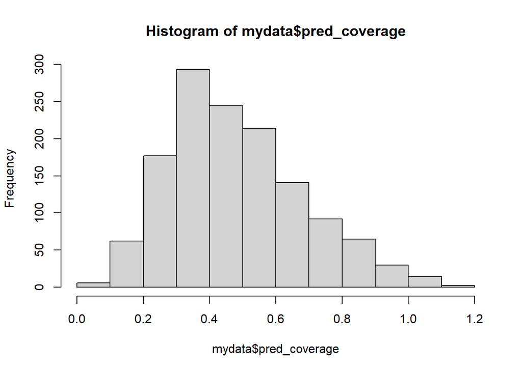

```r
hist(mydata$pred_coverage) # Second problem: how do you go from a predicted 57% probability of Y=1 to predicting Y?
```

```r
mydata <- mydata %>% mutate(yhat = ifelse(pred_coverage >= 0.5, 1, 0)) # What happens if we assume a cutoff (Yhat >= 50% means Yhat = 1)? How good is our match then?
table(mydata$coverage, mydata$yhat) # We incorrectly match 34% of the data!
```

```
##
##       0   1
##   0 513 182
##   1 269 376
```

## Logit and Probit Models

Instead of an LPM, let’s try estimating logit and probit models of the same equation:

```r
# Logit
m2 <- glm(coverage ~ age + sex + bmi + children + smoker,data=mydata,
          family='binomial'(link='logit')) # since we have binary data

# Probit
m3 <- glm(coverage ~ age + sex + bmi + children + smoker,data=mydata,
          family='binomial'(link='probit')) # since we have binary data

msummary(list("LPM"=m1,"Logit"=m2,"Probit"=m3),
         vcov=c(rep("robust",3)),
         stars=c('*' = .1, '**' = .05, '***' = .01))
```

|  | LPM | Logit | Probit |
| --- | --- | --- | --- |
| (Intercept) | −0.228*** | −3.453*** | −2.083*** |
|  | (0.068) | (0.373) | (0.222) |
| age | 0.000 | 0.001 | 0.000 |
|  | (0.001) | (0.004) | (0.003) |
| sexmale | −0.026 | −0.120 | −0.078 |
|  | (0.025) | (0.120) | (0.073) |
| bmi | 0.018*** | 0.089*** | 0.054*** |
|  | (0.002) | (0.011) | (0.006) |
| children | 0.070*** | 0.329*** | 0.202*** |
|  | (0.010) | (0.050) | (0.030) |
| smoker | 0.351*** | 1.665*** | 1.006*** |
|  | (0.030) | (0.166) | (0.098) |
| Num.Obs. | 1340 | 1340 | 1340 |
| R2 | 0.162 |  |  |
| R2 Adj. | 0.158 |  |  |
| AIC | 1721.2 | 1632.9 | 1633.0 |
| BIC | 1757.6 | 1664.1 | 1664.2 |
| F | 69.345 | 36.101 | 39.556 |
| RMSE | 0.46 | 0.46 | 0.46 |
| Std.Errors | Robust | Robust | Robust |

* p < 0.1, ** p < 0.05, *** p < 0.01

What do these coefficients mean? Why are the logit and probit so different?

Recall that we need to compare the **marginal effects** across regressions, as the actual coefficient magnitudes are meaningless without making the appropriate transformations. Let’s calculate each type of marginal effect for the logit model (doing so for the probit model is very similar)

```r
# 1. Each individual marginal effect
allmarginaleffects <- marginaleffects(m2) # Gives you individual ME for all variables/observations
# View(allmarginaleffects) # sort by p-value to see high-impact factors

# 2. and 4. MER and MEM: use the datagrid() function
summary(marginaleffects(m2, datagrid(age  =50, sex = "male", bmi = 50, children = 0, smoker = 1, grid.type = 'counterfactual')))
```

```
##       Term      Contrast     Effect Std. Error z value   Pr(>|z|)      2.5 %
## 1      age         dY/dX  4.849e-05  0.0002815  0.1722 0.86324709 -0.0005033
## 2      sex male - female -7.520e-03  0.0076177 -0.9871 0.32357014 -0.0224503
## 3      bmi         dY/dX  5.867e-03  0.0009252  6.3417 2.2718e-10  0.0040540
## 4 children         dY/dX  2.177e-02  0.0063080  3.4504 0.00055972  0.0094018
## 5   smoker         dY/dX  1.100e-01  0.0209084  5.2606 1.4357e-07  0.0690113
##      97.5 %
## 1 0.0006002
## 2 0.0074107
## 3 0.0076807
## 4 0.0341286
## 5 0.1509706
##
## Model type:  glm
## Prediction type:  response
```

```r
# 3. AME
summary(marginaleffects(m2)) # This gives you AME
```

```
##       Term      Contrast     Effect Std. Error z value   Pr(>|z|)     2.5 %
## 1      age         dY/dX  0.0001532   0.000897  0.1708    0.86436 -0.001605
## 2      sex male - female -0.0249919   0.024993 -0.9999    0.31734 -0.073978
## 3      bmi         dY/dX  0.0185458   0.001965  9.4398 < 2.22e-16  0.014695
## 4 children         dY/dX  0.0687911   0.009896  6.9516 3.6108e-12  0.049396
## 5   smoker         dY/dX  0.3476378   0.028799 12.0712 < 2.22e-16  0.291193
##     97.5 %
## 1 0.001911
## 2 0.023994
## 3 0.022396
## 4 0.088186
## 5 0.404082
##
## Model type:  glm
## Prediction type:  response
```

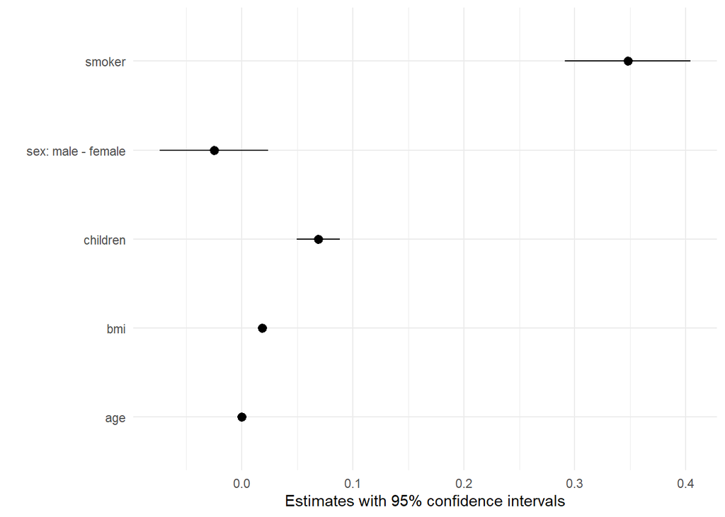

```r
plot(marginaleffects(m2)) # Convenience plot
```

```r
# 4. MEM:
summary(marginaleffects(m2, datagrid()))
```

```
##       Term      Contrast     Effect Std. Error z value   Pr(>|z|)     2.5 %
## 1      age         dY/dX  0.0001828   0.001070  0.1708    0.86437 -0.001915
## 2      sex male - female -0.0299128   0.029954 -0.9986    0.31797 -0.088621
## 3      bmi         dY/dX  0.0221261   0.002601  8.5066 < 2.22e-16  0.017028
## 4 children         dY/dX  0.0820711   0.012552  6.5383 6.2236e-11  0.057469
## 5   smoker         dY/dX  0.4147487   0.040565 10.2243 < 2.22e-16  0.335242
##     97.5 %
## 1 0.002281
## 2 0.028795
## 3 0.027224
## 4 0.106673
## 5 0.494255
##
## Model type:  glm
## Prediction type:  response
```

Finally, suppose that we want to test the joint hypothesis of age and sex on coverage decisions. We can do this in a nonlinear regression model using the Wald test. To run this test, we need to have stored an object with the full model (e.g., including age and sex) and a restricted model (where, under the null hypothesis, these coefficients are forced to be zero):

```r
# Full model is m2 -- already estimated
restricted <- glm(coverage ~ bmi + children + smoker,data=mydata,
          family='binomial'(link='logit')) # Restricted model is where age and sex are both 0
lmtest::waldtest(m2,restricted)
```

```
## Wald test
##
## Model 1: coverage ~ age + sex + bmi + children + smoker
## Model 2: coverage ~ bmi + children + smoker
##   Res.Df Df      F Pr(>F)
## 1   1334
## 2   1336 -2 0.5159 0.5971
```

What does this test tell us?

## Poisson Regression

Now, suppose that our outcome of interest is not whether or not an individual purchased insurance, but the number of health visits they selected in a year.

### Preliminaries

First, I will simulate some data and bake in some correlations. You can mostly ignore this code

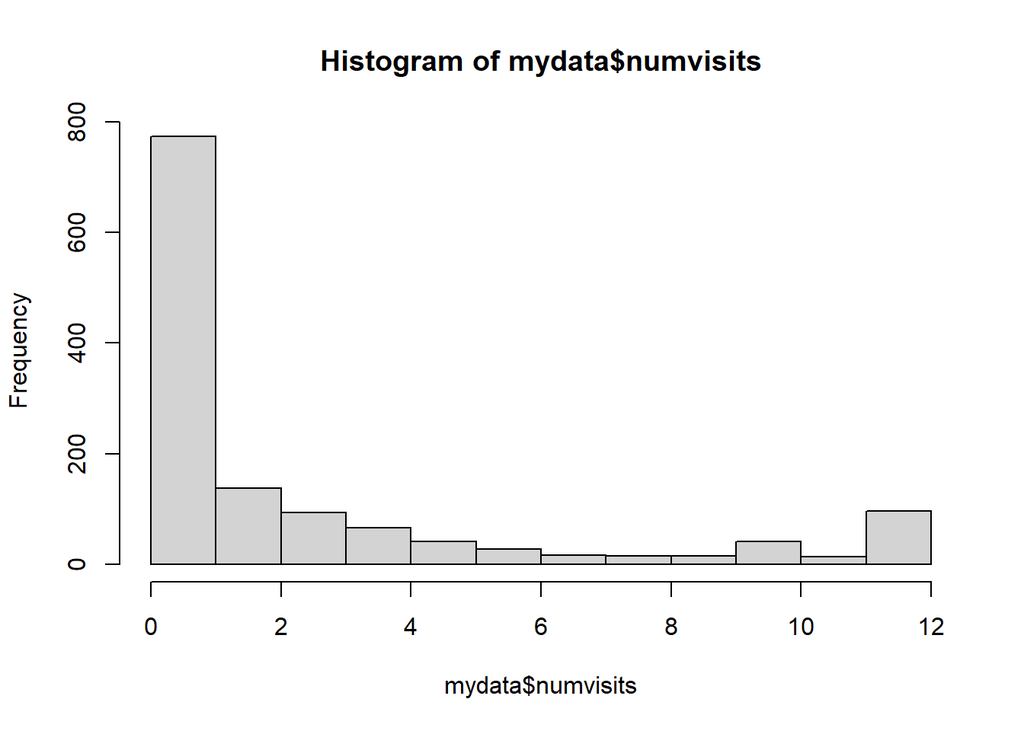

```r
mydata$numvisits <- rpois(1340,2) # Base numvisits
# Now bake in some correlation
mydata <- mydata %>%
  mutate(numvisits = ifelse(age >= 65,round(numvisits*1.5),numvisits)) %>%
  mutate(numvisits = ifelse(age < 35,round(numvisits*0.5),numvisits)) %>%
  mutate(numvisits = ifelse(sex == "male",round(numvisits*0.8),numvisits)) %>%
  mutate(numvisits = numvisits * bmi/31) %>%
  mutate(numvisits = ifelse(numvisits > 10, 10, numvisits)) %>%
  mutate(numvisits = ifelse(smoker == 1, numvisits * 2, numvisits)) %>%
  mutate(numvisits = numvisits * expenses/9000) %>%
  mutate(numvisits = ifelse(numvisits > 10, 10, numvisits)) %>%
  mutate(numvisits = ifelse(coverage == 1,round(numvisits*1.2),numvisits))
mydata$numvisits <- as.integer(mydata$numvisits)
hist(mydata$numvisits)
```

You can see that after the simulations, the distribution of the number of visits looks pretty similar to how it would look if we could use claims data.

### Poisson Regression

Let’s use all of our variables to model the decision to choose health visits. In particular, suppose that we are after the impact of insurance coverage on total utilization (measured in visit counts)?

```r
m_poisson <- glm(numvisits ~ coverage + age + sex + bmi + children + smoker,data=mydata,
                 family = "poisson"(link = "log")) # Why is our link function the log function?
m_naive <- lm(numvisits ~ coverage + age + sex + bmi + children + smoker,data=mydata) # Naive OLS
msummary(list("Naive"=m_naive,"Poisson"=m_poisson),
         vcov=c(rep("robust",2)),
         stars=c('*' = .1, '**' = .05, '***' = .01))
```

|  | Naive | Poisson |
| --- | --- | --- |
| (Intercept) | −4.327*** | −2.221*** |
|  | (0.399) | (0.180) |
| coverage | 0.869*** | 0.480*** |
|  | (0.139) | (0.062) |
| age | 0.081*** | 0.033*** |
|  | (0.005) | (0.002) |
| sexmale | −0.229* | −0.106* |
|  | (0.139) | (0.058) |
| bmi | 0.076*** | 0.031*** |
|  | (0.012) | (0.005) |
| children | 0.017 | 0.014 |
|  | (0.058) | (0.024) |
| smoker | 5.413*** | 1.482*** |
|  | (0.279) | (0.056) |
| Num.Obs. | 1340 | 1340 |
| R2 | 0.525 |  |
| R2 Adj. | 0.523 |  |
| AIC | 6317.5 | 5395.5 |
| BIC | 6359.1 | 5431.9 |
| F | 153.020 | 221.492 |
| RMSE | 2.54 | 2.68 |
| Std.Errors | Robust | Robust |

* p < 0.1, ** p < 0.05, *** p < 0.01

We interpret these regressions, again, by looking at the marginal effects (in this case, we can also look at rate ratios; the preference really depends on the field/journal more than the research question).

```r
exp(m_poisson$coefficients)-1 # What is the marginal effect for coverage? What is the rate ratio?
```

```
## (Intercept)    coverage         age     sexmale         bmi    children
## -0.89145298  0.61588349  0.03383080 -0.10055734  0.03145207  0.01452864
##      smoker
##  3.40099326
```

### Testing for Dispersion

We also need to test for overdispersion in order to run a Poisson model. That is, we want to test whether the mean and variance of our sample data are equivalent.

```r
var(mydata$numvisits)/mean(mydata$numvisits) # Lots of overdisperson! Could bootstrap this to get a CI.
```

```
## [1] 5.177809
```

How does that affect our estimation decision? What can we do if we suffer from overdispersion?

## Hurdle Model

Given that we have so much overdispersion, the Poisson model may not be the best choice – we could look at a zero-inflated model or a negative binomial approach. But let’s also consider the fact that many individuals may not use **any** care in a year, so that `numvisits=0`. Does our Poisson model capture that well?

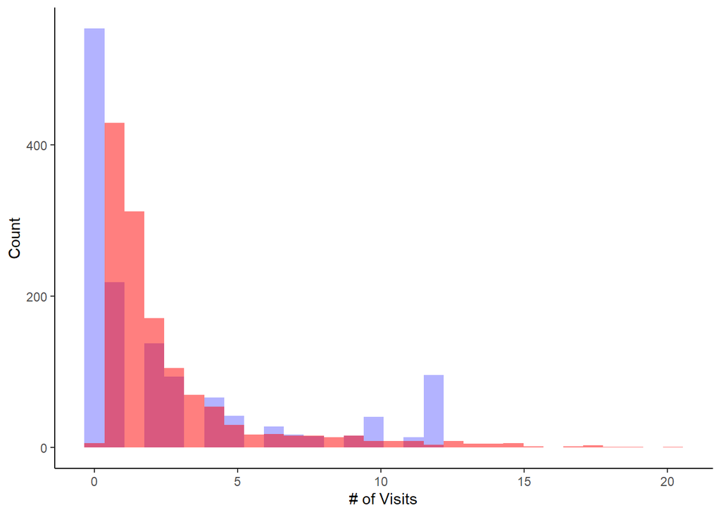

```r
mydata$predicted_visits <- predict(m_poisson, type = "response")
ggplot(mydata)+
  geom_histogram(aes(x=numvisits),position='dodge',fill='blue',alpha=0.3)+
  geom_histogram(aes(x=predicted_visits),position='dodge',fill='red',alpha=0.5)+
  theme_classic()+
  labs(x="# of Visits",y="Count")
```

```r
# sum the probabilities of a 0 count for each mean
exp <- sum(dpois(x = 0, lambda = mydata$predicted_visits))
round(exp) # predicted number of 0's
```

```
## [1] 335
```

```r
sum(mydata$numvisits == 0) # Observed number of 0's
```

```
## [1] 554
```

Not really.

Instead, what if we estimated a hurdle model where we modeled the decision to seek **any** care (extensive margin) separately from the decision of how many visits to have (intensive margin). Note that when estimating a hurdle model, we have some package conflict issues with `modelsummary()` so our tables won’t look quite as nice here.

```r
mod.hurdle <- hurdle(numvisits ~ age + sex + bmi + children + smoker + coverage, data = mydata)
  # First, suppose we have same covariates in both stage of the model

# Model summary doesn't work as well with the pscl package
summary(mod.hurdle)$coefficients
```

```
## $count
##                Estimate  Std. Error   z value      Pr(>|z|)
## (Intercept) -0.87654784 0.128243479 -6.835029  8.198870e-12
## age          0.01415147 0.001460298  9.690805  3.299171e-22
## sexmale     -0.09668025 0.036157180 -2.673888  7.497751e-03
## bmi          0.03026293 0.002921177 10.359844  3.775776e-25
## children    -0.01571920 0.015093060 -1.041485  2.976504e-01
## smoker       1.42169643 0.038706803 36.729885 2.435736e-295
## coverage     0.30923432 0.042714319  7.239594  4.500306e-13
##
## $zero
##                Estimate  Std. Error    z value     Pr(>|z|)
## (Intercept) -5.15386629 0.436378495 -11.810541 3.443368e-32
## age          0.09277916 0.005676492  16.344452 4.764337e-60
## sexmale     -0.22591876 0.137406837  -1.644160 1.001432e-01
## bmi          0.04127011 0.011776807   3.504355 4.577152e-04
## children     0.20081994 0.058471972   3.434465 5.937250e-04
## smoker       0.91748752 0.187916005   4.882434 1.047842e-06
## coverage     0.97208277 0.150435087   6.461809 1.034588e-10
```

```r
# How does it do for prediction?
sum(predict(mod.hurdle, type = "prob")[,1]) # Note: by design, hurdle model gives you exact number of 0s in data
```

```
## [1] 554
```

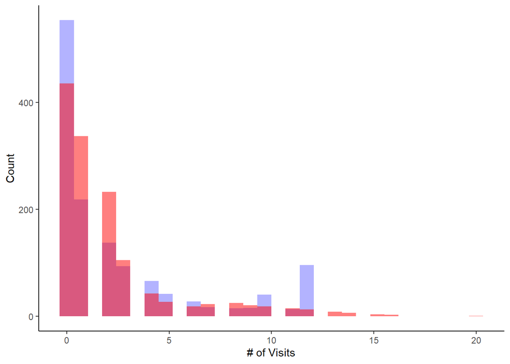

```r
mydata$new_pred <- floor(predict(mod.hurdle, type="response")) # Not sure that this prediction method is correct.
ggplot(mydata)+
  geom_histogram(aes(x=numvisits),position='dodge',fill='blue',alpha=0.3)+
  geom_histogram(aes(x=new_pred),position='dodge',fill='red',alpha=0.5)+
  theme_classic()+
  labs(x="# of Visits",y="Count")
```

## Multinomial Logit Regression

Finally, let’s assume now that everyone in our data set has to have an MD visit, and either chooses (0) no treatment,(1) medication, or (2) surgery. How can we model the choice between these options? Multinomial logit!

### Preliminaries

Some more simulation of data:

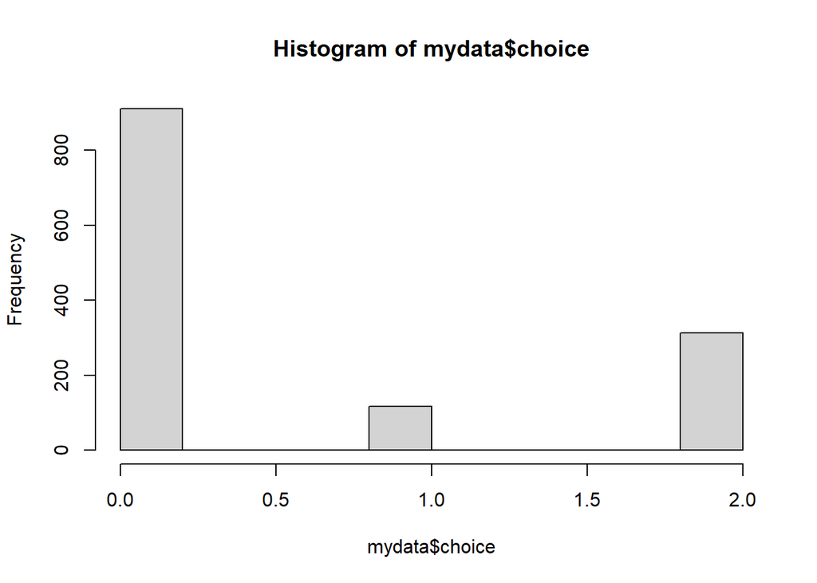

```r
mydata$choice <- sample(c(0,1,2),size=1340,replace=T,prob=c(0.5,0.25,0.25)) # Base choices
# Now bake in some correlation
mydata <- mydata %>%
  mutate(choice = ifelse(age >= 65,round(choice*1.5),choice)) %>%
  mutate(choice = ifelse(choice > 2, 2, choice)) %>%
  mutate(choice = ifelse(age < 35,round(choice*0.5),choice)) %>%
  mutate(choice = ifelse(choice < 0, 0, choice)) %>%
  mutate(choice = ifelse(sex == "male",round(choice*1.5),choice)) %>%
  mutate(choice = ifelse(choice > 2, 2, choice)) %>%
  mutate(choice = ifelse(bmi >= 32 & choice == 2,sample(c(0,1),replace=T,prob=c(0.3,0.7)), choice)) %>%
  mutate(choice = ifelse(smoker == 1 & choice == 2,sample(c(0,1),replace=T,prob=c(0.5,0.5)), choice)) %>%
  mutate(choice = ifelse(smoker == 1 & choice == 1,sample(c(0,1),replace=T,prob=c(0.7,0.3)), choice)) %>%
  mutate(choice = ifelse(expenses >= 17000,round(choice*1.5),choice)) %>%
  mutate(choice = ifelse(choice > 2, 2, choice)) %>%
  mutate(choice = ifelse(coverage == 1,round(choice*1.5),choice)) %>%
  mutate(choice = ifelse(choice > 2, 2, choice))
hist(mydata$choice)
```

This shows us the choices individuals make in our (made up) data set. Now let’s estimate!

### Estimation

First, we select our comparison outcome (in this case, no treatment). The best way to characterize this variable in R (for our package to understand it) is as a **factor**, which includes both a number ID and a value label for each choice in the discrete set. We’ve already been working with these a little bit (as dummy variables), but now we want to really have a 3-plus level factor variable for our multinomial logit to make sense.

Again, `modelsummary()` won’t work well here, so we’ll use a separate package to make some tables.

```r
mydata$choice <- factor(mydata$choice,levels=c(0,1,2),labels=c("Monitoring","Medication","Surgery"))

mydata$region <- factor(mydata$region,levels=c("northeast","northwest","southeast","southwest"),labels=c("northeast","northwest","southeast","southwest"))
  # Let's us include this straight and calculate dummies automatically

mydata$choice_relative <- relevel(mydata$choice, ref = "Monitoring")
mnl <- multinom(choice_relative ~ age + sex + bmi + children + smoker + expenses + coverage + region,
                data = mydata) # Discuss iterations and output
summary(mnl)
```

```
## Call:
## multinom(formula = choice_relative ~ age + sex + bmi + children +
##     smoker + expenses + coverage + region, data = mydata)
##
## Coefficients:
##            (Intercept)        age    sexmale         bmi   children     smoker
## Medication   -5.959606 0.09493454 -1.3804058  0.09049512 0.08146377 -11.957851
## Surgery      -1.139028 0.01684551  0.4791593 -0.04745202 0.04478515  -3.161988
##                 expenses    coverage regionnorthwest regionsoutheast
## Medication -1.945338e-04 -15.7842443      0.24904210       0.1734079
## Surgery     4.401399e-05   0.9029735     -0.02516824      -0.1779486
##            regionsouthwest
## Medication       0.1689258
## Surgery          0.0557872
##
## Std. Errors:
##             (Intercept)         age      sexmale         bmi     children
## Medication 0.0001596751 0.016335626 0.0001339058 0.011174517 0.0007094588
## Surgery    0.0001499806 0.005036068 0.0001110247 0.006579265 0.0002659048
##                  smoker     expenses     coverage regionnorthwest
## Medication 9.448979e-10 5.836405e-05 3.107943e-10    8.583705e-05
## Surgery    4.154939e-05 7.452419e-06 1.489206e-04    2.757500e-05
##            regionsoutheast regionsouthwest
## Medication    0.0002557649    2.055969e-04
## Surgery       0.0000808326    5.912256e-05
##
## Residual Deviance: 1721.566
## AIC: 1765.566
```

### Presentation

Now that the model has been estimated, let’s try (being the operative word) to present this in a well-formatted and easy-to-understand way. This model is already complicated, so even without the package conflicts it can be tricky to know how to summamrize it. Below are some options–the way you choose to summarize this model will be entirely depeendent on the research context and the parameters you are after.

```r
# Calculate our own significance
z <- summary(mnl)$coefficients/summary(mnl)$standard.errors
p <- (1 - pnorm(abs(z), 0, 1)) * 2

# Presenting the model: some options
# View(tidy(mnl, conf.int = TRUE)) # Can save this as an object to construct your own table

# an HTML version
tidy(mnl, conf.int = TRUE) %>%
  kable() %>%
  kable_styling("basic", full_width = FALSE)
```

| y.level | term | estimate | std.error | statistic | p.value | conf.low | conf.high |
| --- | --- | --- | --- | --- | --- | --- | --- |
| Medication | (Intercept) | -5.9596063 | 0.0001597 | -3.732333e+04 | 0.0000000 | -5.9599193 | -5.9592933 |
| Medication | age | 0.0949345 | 0.0163356 | 5.811503e+00 | 0.0000000 | 0.0629173 | 0.1269518 |
| Medication | sexmale | -1.3804058 | 0.0001339 | -1.030878e+04 | 0.0000000 | -1.3806683 | -1.3801434 |
| Medication | bmi | 0.0904951 | 0.0111745 | 8.098348e+00 | 0.0000000 | 0.0685935 | 0.1123968 |
| Medication | children | 0.0814638 | 0.0007095 | 1.148252e+02 | 0.0000000 | 0.0800733 | 0.0828543 |
| Medication | smoker | -11.9578507 | 0.0000000 | -1.265518e+10 | 0.0000000 | -11.9578507 | -11.9578507 |
| Medication | expenses | -0.0001945 | 0.0000584 | -3.333110e+00 | 0.0008588 | -0.0003089 | -0.0000801 |
| Medication | coverage | -15.7842443 | 0.0000000 | -5.078679e+10 | 0.0000000 | -15.7842443 | -15.7842443 |
| Medication | regionnorthwest | 0.2490421 | 0.0000858 | 2.901336e+03 | 0.0000000 | 0.2488739 | 0.2492103 |
| Medication | regionsoutheast | 0.1734079 | 0.0002558 | 6.779973e+02 | 0.0000000 | 0.1729066 | 0.1739092 |
| Medication | regionsouthwest | 0.1689258 | 0.0002056 | 8.216361e+02 | 0.0000000 | 0.1685229 | 0.1693288 |
| Surgery | (Intercept) | -1.1390278 | 0.0001500 | -7.594502e+03 | 0.0000000 | -1.1393218 | -1.1387339 |
| Surgery | age | 0.0168455 | 0.0050361 | 3.344973e+00 | 0.0008229 | 0.0069750 | 0.0267160 |
| Surgery | sexmale | 0.4791593 | 0.0001110 | 4.315790e+03 | 0.0000000 | 0.4789417 | 0.4793769 |
| Surgery | bmi | -0.0474520 | 0.0065793 | -7.212358e+00 | 0.0000000 | -0.0603471 | -0.0345569 |
| Surgery | children | 0.0447852 | 0.0002659 | 1.684255e+02 | 0.0000000 | 0.0442640 | 0.0453063 |
| Surgery | smoker | -3.1619877 | 0.0000415 | -7.610190e+04 | 0.0000000 | -3.1620691 | -3.1619062 |
| Surgery | expenses | 0.0000440 | 0.0000075 | 5.906000e+00 | 0.0000000 | 0.0000294 | 0.0000586 |
| Surgery | coverage | 0.9029735 | 0.0001489 | 6.063454e+03 | 0.0000000 | 0.9026816 | 0.9032654 |
| Surgery | regionnorthwest | -0.0251682 | 0.0000276 | -9.127195e+02 | 0.0000000 | -0.0252223 | -0.0251142 |
| Surgery | regionsoutheast | -0.1779486 | 0.0000808 | -2.201447e+03 | 0.0000000 | -0.1781071 | -0.1777902 |
| Surgery | regionsouthwest | 0.0557872 | 0.0000591 | 9.435857e+02 | 0.0000000 | 0.0556713 | 0.0559031 |

```r
# This gives you a table of relative risk ratios
tbl_regression(mnl, exp = TRUE)
```

```
## ℹ Multinomial models have a different underlying structure than the models
## gtsummary was designed for. Other gtsummary functions designed to work with
## tbl_regression objects may yield unexpected results.
```

| **Characteristic** | **OR**<sup>1</sup> | **95% CI**<sup>1</sup> | **p-value** |
| --- | --- | --- | --- |
| Medication |  |  |  |
| age | 1.10 | 1.06, 1.14 | <0.001 |
| sex |  |  |  |
| female | — | — |  |
| male | 0.25 | 0.25, 0.25 | <0.001 |
| bmi | 1.09 | 1.07, 1.12 | <0.001 |
| children | 1.08 | 1.08, 1.09 | <0.001 |
| smoker | 0.00 | 0.00, 0.00 | <0.001 |
| expenses | 1.00 | 1.00, 1.00 | <0.001 |
| coverage | 0.00 | 0.00, 0.00 | <0.001 |
| region |  |  |  |
| northeast | — | — |  |
| northwest | 1.28 | 1.28, 1.28 | <0.001 |
| southeast | 1.19 | 1.19, 1.19 | <0.001 |
| southwest | 1.18 | 1.18, 1.18 | <0.001 |
| Surgery |  |  |  |
| age | 1.02 | 1.01, 1.03 | <0.001 |
| sex |  |  |  |
| female | — | — |  |
| male | 1.61 | 1.61, 1.62 | <0.001 |
| bmi | 0.95 | 0.94, 0.97 | <0.001 |
| children | 1.05 | 1.05, 1.05 | <0.001 |
| smoker | 0.04 | 0.04, 0.04 | <0.001 |
| expenses | 1.00 | 1.00, 1.00 | <0.001 |
| coverage | 2.47 | 2.47, 2.47 | <0.001 |
| region |  |  |  |
| northeast | — | — |  |
| northwest | 0.98 | 0.98, 0.98 | <0.001 |
| southeast | 0.84 | 0.84, 0.84 | <0.001 |
| southwest | 1.06 | 1.06, 1.06 | <0.001 |

<sup>1</sup> OR = Odds Ratio, CI = Confidence Interval

```r
# Interperting the model
exp(coef(mnl)) # this gives us relative risk ratios -- see slides about odds ratios
```

```
##            (Intercept)      age   sexmale       bmi children       smoker
## Medication 0.002580928 1.099587 0.2514765 1.0947162 1.084874 6.408722e-06
## Surgery    0.320130093 1.016988 1.6147164 0.9536562 1.045803 4.234150e-02
##             expenses     coverage regionnorthwest regionsoutheast
## Medication 0.9998055 1.396336e-07       1.2827960       1.1893511
## Surgery    1.0000440 2.466928e+00       0.9751458       0.8369854
##            regionsouthwest
## Medication        1.184032
## Surgery           1.057373
```

```r
# Calculating marginal effects:
myme <- marginaleffects(mnl, type = "probs")
# Warning: The standard errors estimated by `marginaleffects` do not match those
# produced by Stata for `nnet::multinom` models. Please be very careful when
# interpreting the results.
summary(myme)
```

```
##         Group     Term              Contrast     Effect Std. Error  z value
## 1  Monitoring      age                 dY/dX -6.780e-03  1.203e-03  -5.6352
## 2  Monitoring      sex         male - female -5.076e-03  5.596e-03  -0.9070
## 3  Monitoring      bmi                 dY/dX  2.551e-03  1.088e-03   2.3454
## 4  Monitoring children                 dY/dX -1.012e-02  2.960e-04 -34.1941
## 5  Monitoring   smoker                 dY/dX  1.001e+00  3.573e-02  28.0273
## 6  Monitoring expenses                 dY/dX  2.742e-06  3.904e-06   0.7023
## 7  Monitoring coverage                 dY/dX  6.012e-01  4.986e-02  12.0581
## 8  Monitoring   region northwest - northeast -7.702e-03  8.037e-04  -9.5828
## 9  Monitoring   region southeast - northeast  1.701e-02  1.121e-03  15.1788
## 10 Monitoring   region southwest - northeast -1.562e-02  5.051e-04 -30.9337
## 11 Medication      age                 dY/dX  5.369e-03  1.195e-03   4.4938
## 12 Medication      sex         male - female -8.699e-02  5.800e-03 -14.9983
## 13 Medication      bmi                 dY/dX  5.916e-03  7.224e-04   8.1890
## 14 Medication children                 dY/dX  4.226e-03  2.567e-04  16.4625
```

[output cut: 50 more lines]